# cshea26_OriginalHomeworkCode_04

Carly S McDermott

2025-03-14

INFO: - Z and T tests are used to evaluate whether a given sample statistic (e.g., a mean or proportion) deviates significantly from what is expected under a null model or whether two samples statistics deviate significantly from one another.

- We REJECT a H0 if the p value obtained for a given Z or T test statistic is < α CIs for our sample statistic are calculated as mean ± T(1−α/2) or Z(1−α/2) x SEM, and we can REJECT a H0 if the (1-α) CI around does not include the expected value of the statistic When the sample size > 30, or when we are dealing with proportions, we use Z quantiles for calculating CIs and p values, but for sample size < 30, we use T quantiles

## 1) Write a simple R function, Z.prop.test(), that can perform one- or two-sample Z-tests for proportion data, using the following guidelines:

- Your function should take the following arguments: p1 and n1 (no default) representing the estimated proportion and sample size (i.e., based on your sample data); p2 and n2 (both defaulting to NULL) that contain a second sample’s proportion and sample size data in the event of a two-sample test; p0 (no default) as the expected value for the population proportion; and alternative (default “two.sided”) and conf.level (default 0.95), to be used in the same way as in the function t.test().
- When conducting a two-sample test, it should be p1 that is tested as being smaller or larger than p2 when alternative=“less” or alternative=“greater”, the same as in the use of x and y in the function t.test(). The function should perform a one-sample Z-test using p1, n1, and p0 if either p2 or n2 (or both) is NULL.
- The function should contain a check for the rules of thumb we have talked about ($n * p > 5$ and $n * (1-p) > 5$) to ensure the validity of assuming the normal distribution in both the one- and two-sample settings. If this is violated, the function should still complete but it should also print an appropriate warning message.
- The function should return a list containing the members Z (the test statistic), P (the appropriate p value), and CI (the two-sided CI with respect to “conf.level” around p1 in the case of a one-sample test and around p2-p1 in the case of a two-sample test). - For all test alternatives (“two.sided”, “greater”, “less”), calculate symmetric CIs based on quantiles of the normal distribution rather than worrying about calculating single-limit confidence bounds.

```r
#start with determining if we require a one or two sample test (first part of the function determines if we require a one sample and then goes into different alternatives within the one sample z test)
Z.prop.test <- function(p1, n1, p2 = NULL, n2 = NULL, p0, alternative = "two.sided", conf.level = 0.95) {
  if (is.null(p2) || is.null(n2)) {
    z <- (p1 - p0)/sqrt(p0*(1 -p0)/n1) #mean of sample observations minus expected mean, divided by sample standard of deviations divided by square root of number of sample observations

    if (alternative == "greater") {
      pval <- pnorm(z, lower.tail = FALSE) #checking if alternative is greater or less than (indicates if we need to use upper or lower tail)
    } else if (alternative == "less") {
      pval <- pnorm(z, lower.tail = TRUE)
    } else if (alternative == "two.sided") { #otherwise checking if z is greater than zero, if so we do a lower tail test, if not we do an upper tail test
      if (z > 0) {
        pval <- 2 * pnorm(z, lower.tail = FALSE)
      } else {
        pval <- 2 * pnorm(z, lower.tail = TRUE)
      }
    }

    #creating warning message to ensure the validity of assuming the normal distribution
    if ((n1 * p0 < 5) || (n1 * (1-p0) < 5)) {
      warning("invalid assumption of normal distribution")
    }

    lower <- p1 - qnorm(0.975) * sqrt(p1 * (1 - p1)/n1)
    upper <- p1 + qnorm(0.975) * sqrt(p1 * (1 - p1)/n1)
    ci <- c(lower, upper) #creating confidence interval based on upper and lower bounds (.975 and .025)

    result <- list(test.type = "One-Sample Proportion Z-test",
                                alternative = alternative,
                                z.test.stat = as.numeric(z),
                                p.value = as.numeric(pval),
                                confidence.interval = ci)
    return(result)
  }

  #for the two sample test:
  else {
    pstar <- ((p1*n1) + (p2*n2))/(n1 + n2) #pstar is the pooled proportion of p; originally i had it as p0 here but Akiva suggested not doing this since that is used for the one sample test (not the 2)

    z <- (p2 - p1)/sqrt((pstar * (1 - pstar)) * (1/n1 + 1/n2))

    if (alternative == "greater") {
        pval <- pnorm(z, lower.tail = FALSE)
      }
      if (alternative == "less") {
        pval <- pnorm(z, lower.tail = TRUE)
      }
      if (alternative == "two.sided") {
        pval <- 1 - pnorm(z, lower.tail = TRUE) + pnorm(z, lower.tail = FALSE)
          }

    if ((n1 * pstar < 5) | (n1 * (1 - pstar) < 5 ) | (n2 * pstar < 5) | (n2 * (1 - pstar) < 5)) {
      warning("invalid assumption of normal distribution")
  }
  crit <- qnorm((1 + conf.level)/2) # using this to find the critical value
  se <- crit*sqrt((p1*(1-p1))/n1) + (p2 * (1-p2)/n2)
  upper <- (p1 - p2) + se
  lower <- (p1 - p2) - se
  ci <- c(lower, upper)

    result2 <- list(test.type = "Two-Sample Proportion Z-test",
                                alternative = alternative,
                                z.test.statistic = as.numeric(z),
                                p.value = as.numeric(pval),
                                confidence.interval = ci,
                                critical.value = as.numeric(crit))     #here i also returned critical value
    return(result2)
  }
}
```

## Question 2) The dataset from Kamilar and Cooper has in it a large number of variables related to life history and body size.

- For this exercise, the end aim is to fit a simple linear regression model to predict longevity (MaxLongevity_m) measured in months from species’ brain size (Brain_Size_Species_Mean) measured in grams. Do the following for both longevity~brain size and log(longevity)~log(brain size):

## Part 1:

Fit the regression model and, using {ggplot2}, produce a scatterplot with the fitted line superimposed upon the data. Append the the fitted model equation to your plot (HINT: use the function geom_text())

```r
#cleaning data
library(curl)
```

```r
library(ggplot2)
library(ggpubr)
library(gridExtra)

data <- curl("https://raw.githubusercontent.com/fuzzyatelin/fuzzyatelin.github.io/master/AN588_Fall23/KamilarAndCooperData.csv") #load data
data <- read.csv(data, header = TRUE, sep = ",", stringsAsFactors = FALSE)
data <- data[complete.cases(data$Brain_Size_Species_Mean, data$MaxLongevity_m), ]
sum(is.na(data$Brain_Size_Species_Mean))
```

```
## [1] 0
```

```r
sum(is.na(data$MaxLongevity_m))
```

```
## [1] 0
```

```r
# clean data to get longevity and brain size (NA categories), now only doing it in these two categories instead of entire document
```

```r
#creating model1: longevity ~ brain size
model1 <- lm(MaxLongevity_m ~ Brain_Size_Species_Mean, data = data) #coef returns standardized model regression coefficients
intercept1 <- coef(model1)["(Intercept)"]
slope1 <- coef(model1)["Brain_Size_Species_Mean"]

# creating model2: log(longevity) ~ log(brain size), doing the same as above but with the logs
model2 <- lm(log(MaxLongevity_m) ~ log(Brain_Size_Species_Mean), data = data)
intercept2 <- coef(model2)["(Intercept)"]
slope2 <- coef(model2)["log(Brain_Size_Species_Mean)"]
```

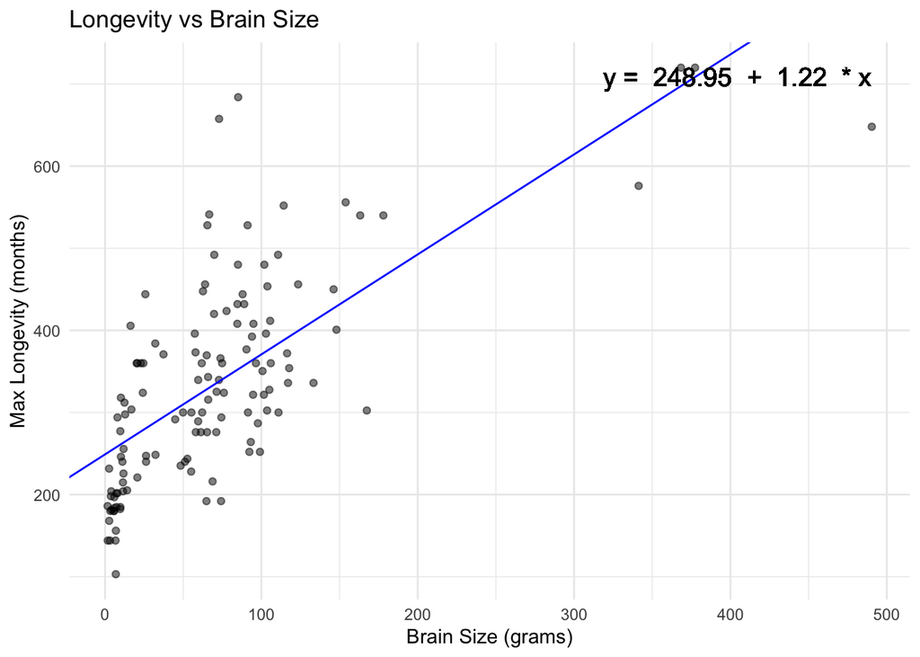

```r
#plotting model1 in ggplot as p1
p1 <- ggplot(data, aes(x = Brain_Size_Species_Mean, y = MaxLongevity_m)) +
  geom_point(alpha = 0.5) +
  geom_abline(intercept = intercept1, slope = slope1, color = "blue") + geom_text(aes(x = max(Brain_Size_Species_Mean), y = max(MaxLongevity_m),
#this next part gives me my equation for the line
                label = paste("y = ", round(coef(model1)[1], 2), " + ", round(coef(model1)[2], 2), " * x")),
            hjust = 1, vjust = 1, size = 5) +
  labs(title = "Longevity vs Brain Size", x = "Brain Size (grams)", y = "Max Longevity (months)") +  theme_minimal()
p1
```

[figure not shown]

```r
#p2 represents linear regression plot for logs
p2 <- ggplot(data, aes(x = log(Brain_Size_Species_Mean), y = log(MaxLongevity_m))) +
  geom_point(alpha = 0.5) +
  geom_abline(intercept = intercept2, slope = slope2, color = "red") +
  geom_text(aes(x = max(log(Brain_Size_Species_Mean)), y = max(log(MaxLongevity_m)),
                label = paste("y = ", round(coef(model2)[1], 2), " + ", round(coef(model2)[2], 2), " * x")),
            hjust = 1, vjust = 1) +
  labs(title = "Log of Brain Size vs. Log of Longevity", x = "Log of Longevity", y = "Log of Brain Size") +
  theme_minimal()
p2
```

[output not shown]

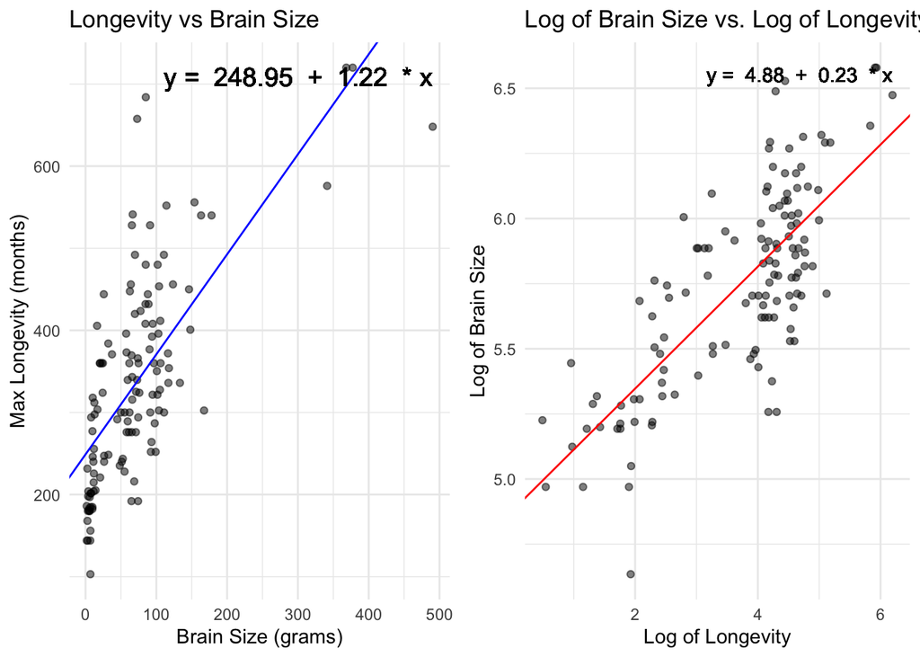

```r
grid.arrange(p1, p2, ncol = 2)
```

- tried to use geom_smooth() but didn’t like how the line it created wasn’t making contact with the x axis. is there a way to fix this while still using geom smooth? instead here i just plotted a line equal to the intercept and slope i established above with my two models

### Alternative Method (based on the model i created for Quesiton 1 = I like this way more)

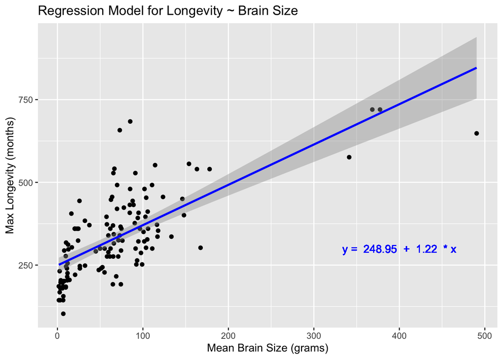

```r
model1 <- lm(MaxLongevity_m ~ Brain_Size_Species_Mean, data = data) #coef returns standardized model regression coefficients

# using the function i created above
equation1 <- function(x) {
   label = paste("y = ", round(coef(x)[1], 2), " + ", round(coef(x)[2], 2), " * x")
}
mod1 <- equation1(model1)

#plotting the function for model 1
datas <- data.frame(cbind(data$Brain_Size_Species_Mean, data$MaxLongevity_m))
names(datas) <- c("Brain_size", "Max_longevity")

g <- ggplot(data = datas, aes(x = Brain_size, y = Max_longevity)) + # building the plot
  xlab("Mean Brain Size (grams)") +
  ylab("Max Longevity (months)") +
  ggtitle("Regression Model for Longevity ~ Brain Size")
g <- g + geom_point()  # creates my scatterplot
g <- g + geom_smooth(method = "lm", formula= y~x, color = "blue") # makes the regression line
g <- g + geom_text(x = 400, y = 300, label = mod1, color = "blue") #x and y here center my equation wherever i tell it to
g
```

### Alternative Method (for the log now)

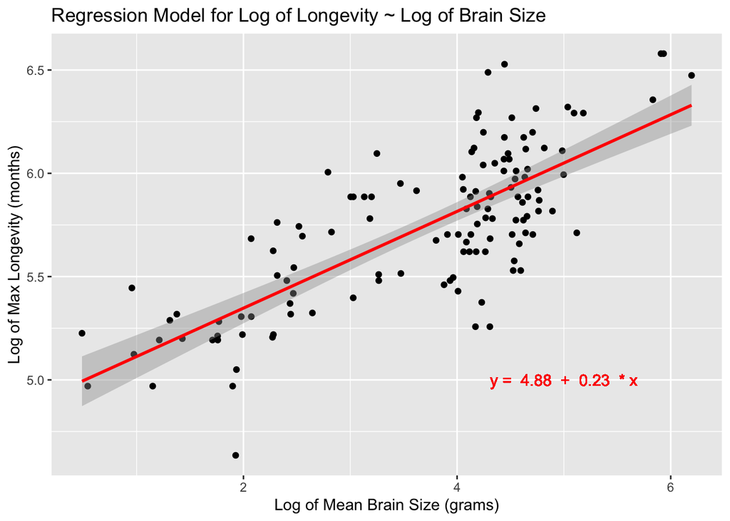

```r
#plotting the function for model2 (log)
datalog <- data.frame(Log_brain_size = log(data$Brain_Size_Species_Mean), Log_max_longevity = log(data$MaxLongevity_m))

model2 <- lm(log(MaxLongevity_m) ~ log(Brain_Size_Species_Mean), data = data)
mod2 <- equation1(model2) #running into an error here where its giving me the equation for my model 1; changed the function equation because i accidentally wrote model1 instead of x

#making plot for model2
b <- ggplot(data = datalog, aes(x = Log_brain_size, y = Log_max_longevity)) +
  xlab("Log of Mean Brain Size (grams)") +
  ylab("Log of Max Longevity (months)") +
  ggtitle("Regression Model for Log of Longevity ~ Log of Brain Size")
b <- b + geom_point() + geom_smooth(method = "lm", color = "red") + geom_text(x = 5, y = 5, label = mod2, color = "red")
b
```

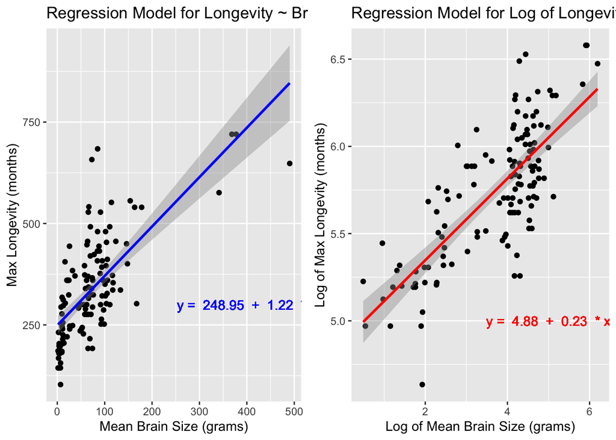

```r
grid.arrange(g, b, ncol = 2)
```

Overall, after playing around with different formatting styles of the regression line/plot, I like how I can integrate my function into my plot by writing an equation directly from it. This is something I struggled with immensely initially, and with help from my peer reviewer, an element in this homework assignment that I am very proud of now.

## Part 2:

```r
w <- data$Brain_Size_Species_Mean #originally had these swapped, they are correct now and align with the summary information below
h <- data$MaxLongevity_m
beta1 <- cor(w, h) * (sd(h)/sd(w))
beta1
```

```
## [1] 1.21799
```

```r
#to determine beta1 for the log plots
w <- log(data$Brain_Size_Species_Mean)
h <- log(data$MaxLongevity_m)
beta1 <- cor(w, h) * (sd(h)/sd(w))
beta1
```

```
## [1] 0.2341496
```

```r
#another way to visualize this information is calling for a summary of the two different models i created
summary(model1) #estimate std. for Brain_Size_Species_Mean is going to be the value that represents beta1
```

```
##
## Call:
## lm(formula = MaxLongevity_m ~ Brain_Size_Species_Mean, data = data)
##
## Residuals:
##     Min      1Q  Median      3Q     Max
## -198.27  -61.92  -17.78   56.16  331.36
##
## Coefficients:
##                         Estimate Std. Error t value Pr(>|t|)
## (Intercept)             248.9523    11.1111   22.41   <2e-16 ***
## Brain_Size_Species_Mean   1.2180     0.1101   11.06   <2e-16 ***
## ---
## Signif. codes:  0 '***' 0.001 '**' 0.01 '*' 0.05 '.' 0.1 ' ' 1
##
## Residual standard error: 90.91 on 126 degrees of freedom
## Multiple R-squared:  0.4928, Adjusted R-squared:  0.4887
## F-statistic: 122.4 on 1 and 126 DF,  p-value: < 2.2e-16
```

```r
summary(model2)
```

```
##
## Call:
## lm(formula = log(MaxLongevity_m) ~ log(Brain_Size_Species_Mean),
##     data = data)
##
## Residuals:
##     Min      1Q  Median      3Q     Max
## -0.6955 -0.1750 -0.0097  0.1788  0.6084
##
## Coefficients:
##                              Estimate Std. Error t value Pr(>|t|)
## (Intercept)                   4.87895    0.06907   70.63   <2e-16 ***
## log(Brain_Size_Species_Mean)  0.23415    0.01781   13.15   <2e-16 ***
## ---
## Signif. codes:  0 '***' 0.001 '**' 0.01 '*' 0.05 '.' 0.1 ' ' 1
##
## Residual standard error: 0.2485 on 126 degrees of freedom
## Multiple R-squared:  0.5784, Adjusted R-squared:  0.5751
## F-statistic: 172.9 on 1 and 126 DF,  p-value: < 2.2e-16
```

- Nonzero value of𝛽1 signifies:
- My guess: the estimated 𝛽1 in both cases yields a non-zero value, meaning that we can reject the null hypothesis H0 which argues that 𝛽1 = 0, and therefore accept the HA (alternative hypothesis) that 𝛽1 does not equal 0.

## Part 3:

Using your model, add lines for the 90 percent confidence and prediction interval bands on the plot and add a legend to differentiate between the lines.

#Part 3: With Prediction Lines and CIs

```r
#for model 1
ci <- predict(model1, interval = "confidence", level = 0.90)
pi <- predict(model1, interval = "prediction", level = 0.90)
```

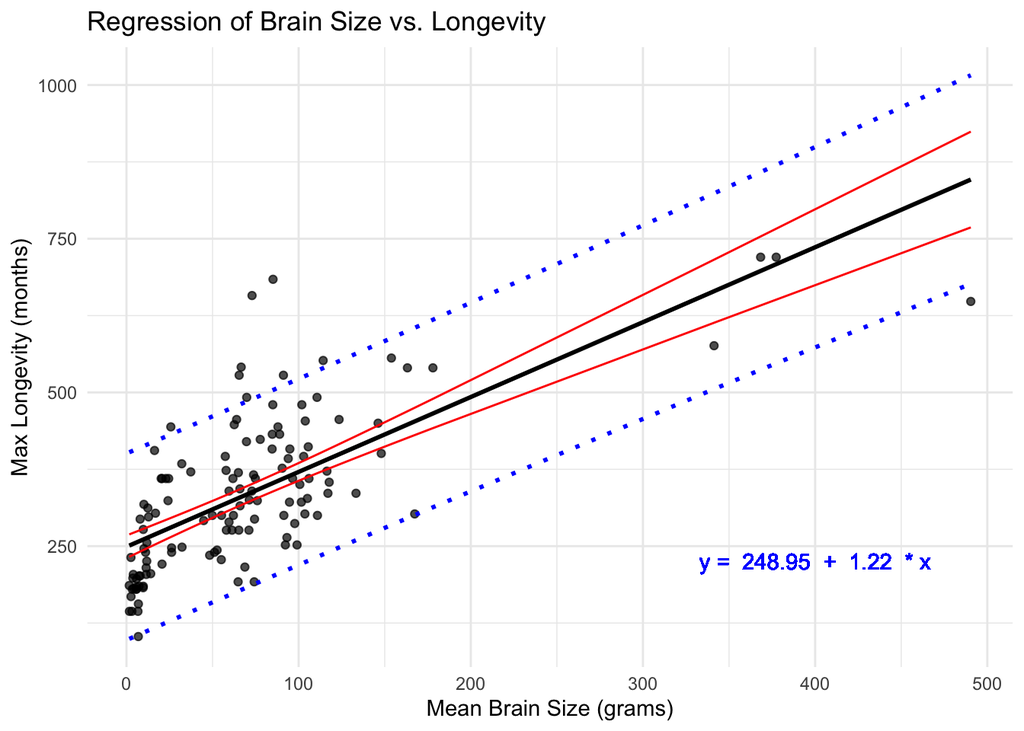

```r
#adding predictions to datas df:
datas <- cbind(datas, ci, pi)
names(datas) <- c("Brain_Size_Species_Mean", "MaxLongevity_m", "CIfit", "CIlwr", "CIupr", "PIfit", "PIlwr", "PIupr")

#make plot for model 1 (alpha = 1 makes my points solid - not transparent)
a <- ggplot(datas, aes(x = Brain_Size_Species_Mean, y = MaxLongevity_m)) +
  geom_point(alpha = .7) +
  labs(x = "Brain Size", y = "Max Longevity",
       title = "Regression of Brain Size vs. Longevity") +
  theme_minimal()
a <- a + geom_text(x = 400, y = 225, label = mod1, color = "blue")

# adding my regression line (black)
a <- a + geom_line(aes(y = CIfit), size = 1)
# then add 90% confidence intervals (dotted red lines)
a <- a + geom_line(aes(y = CIlwr), color = "red", size = .5) +
  geom_line(aes(y = CIupr), color = "red", size = .5)

# then add prediction intervals
a <- a + geom_line(aes(y = PIlwr), linetype = "dotted", color = "blue", size = 1) +
  geom_line(aes(y = PIupr), linetype = "dotted", color = "blue", size = 1)

# making my labels
a <- a + labs(x = "Mean Brain Size (grams)", y = "Max Longevity (months)", title = "Regression of Brain Size vs. Longevity")
a
```

```r
#for model2 (log)
ci_log <- predict(model2, interval = "confidence", level = 0.90)
pi_log <- predict(model2, interval = "prediction", level = 0.90)
```

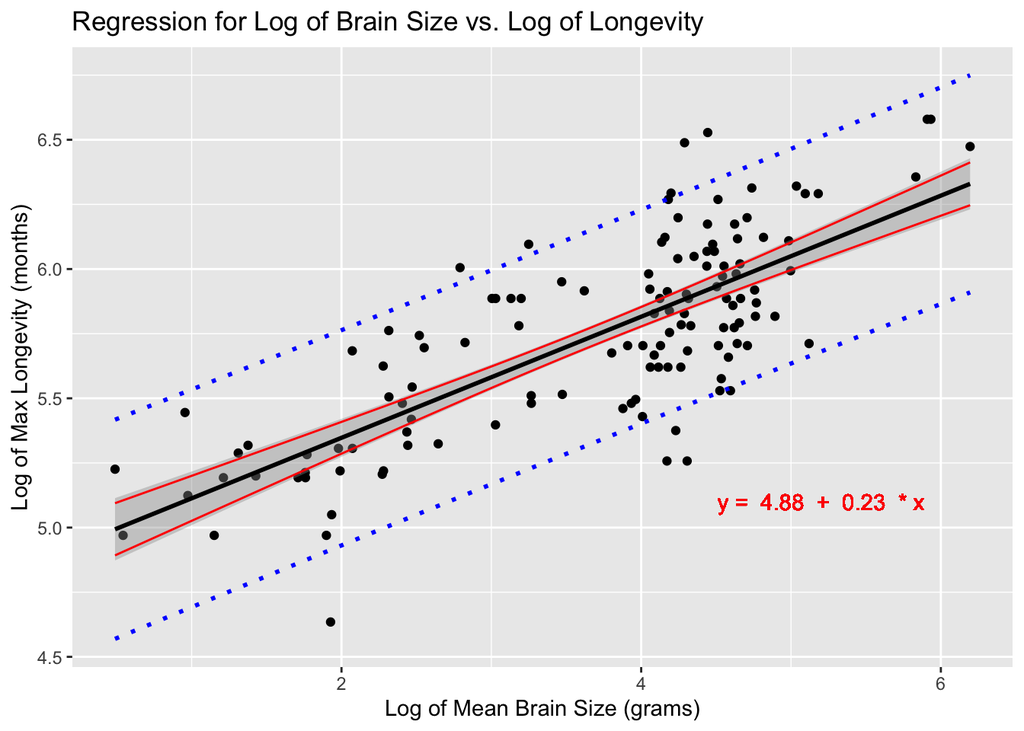

```r
#adding predictions to datalog df:
datalog <- cbind(datalog, ci_log, pi_log)
names(datalog) <- c("Log_brain_size", "Log_max_longevity", "CIfit_log", "CIlwr_log", "CIupr_log", "PIfit_log", "PIlwr_log", "PIupr_log")

#make plot for model 2 (alpha = 1 makes my points solid - not transparent, here i set to .7)
c <- ggplot(data = datalog, aes(x = Log_brain_size, y = Log_max_longevity))
c <- c + geom_point() + geom_smooth(method = "lm", color = "black") + geom_text(x = 5.2, y = 5.1, label = mod2, color = "red") #adding regression line

# then add 90% confidence intervals (dotted red lines)
c <- c + geom_line(aes(y = CIlwr_log), color = "red", size = .5) +
  geom_line(aes(y = CIupr_log), color = "red", size = .5)

# then add prediction intervals
c <- c + geom_line(aes(y = PIlwr_log), linetype = "dotted", color = "blue", size = 1) +
  geom_line(aes(y = PIupr_log), linetype = "dotted", color = "blue", size = 1)

# making my labels and a legend
c <- c + labs(x = "Log of Mean Brain Size (grams)", y = "Log of Max Longevity (months)", title = "Regression for Log of Brain Size vs. Log of Longevity")
c
```

## Part 4:

Produce a point estimate and associated 90 percent PI for the longevity of a species whose brain weight is 800 gm. Do you trust the model to predict observations accurately for this value of the explanatory variable? Why or why not?

```r
#for longevity ~ brain size (not doing it for the log model)
p1 <- predict(model1, newdata = data.frame(Brain_Size_Species_Mean = 800), interval = "prediction", level = 0.90)
p1 #making the data frame only look at a single category is very helpful and prevents R from giving you a million numbers back out
```

```
##        fit      lwr      upr
## 1 1223.345 1021.805 1424.884
```

**Looking at your two models, which do you think is better? Why?** - when asking the model to make predictions for large values that exceed the range for the majority of points in the longevity vs. brain size normal regression, i am not entirely sure that i trust its capacity to predict these values. the log transformed data appears much more evenly distributed and for that reason i trust the log plot/prediction to better capture my data.

^Noted and modified results in accordance with this feedback!

## Final Thoughts/Feedback:

**Final Version Additional Comments:** After going through the comments left by my peer commentator and further testing different models and approaches to plotting my lines, I feel like I better understand how to apply the function I created in Question I to the sequential steps in Question 2. I like how my figures turned out overall! One challenge that I may revisit is creating a legend for my figures., something I wasn’t entirely sure how to do.